# Leitura de Arquivos de Texto no R

# Leitura de Arquivos de Texto no R

Nesta aula, vamos explorar como trabalhar com arquivos estruturados no formato de texto simples (plain text) no R. O R é uma ferramenta poderosa para análise de dados, e esses dados podem estar disponíveis em diferentes tipos de formatos, que se dividem em três categorias principais:

## Tipos de Dados

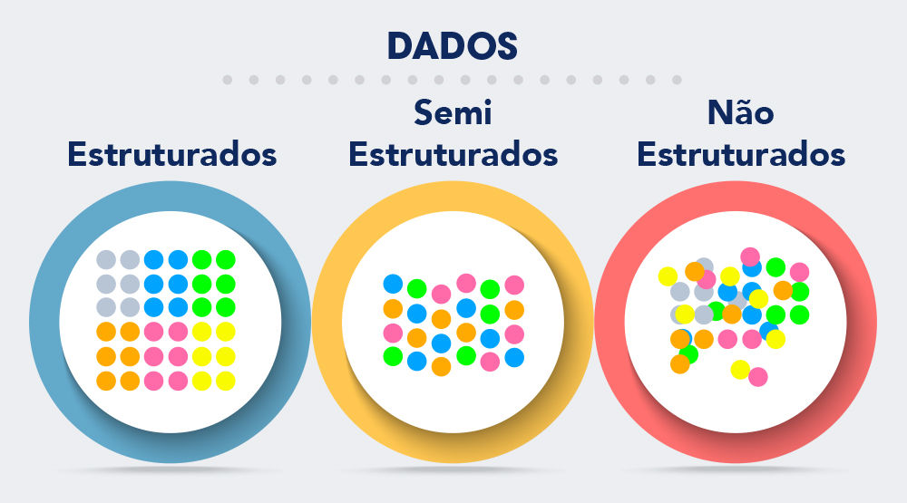

Tipos de Dados

### 1. Dados Estruturados ou Tabulares

Estes são os dados mais comuns em análise de dados. Eles estão organizados em formato de tabela, onde: - **Linhas** correspondem às observações. - **Colunas** correspondem às variáveis.

Esses dados geralmente são disponibilizados como: - **Arquivos de texto simples (CSV, TSV, etc.)**: Arquivos que podem ser abertos em editores de texto como o Bloco de Notas ou o RStudio. - **Planilhas eletrônicas**: Tabelas armazenadas em arquivos binários (como Excel). - **Tabelas em bancos de dados relacionais**: Comumente acessadas por meio de SQL.

### 2. Dados Semi-estruturados

Esses dados têm uma estrutura definida, mas não são organizados em tabelas simples: - **Arquivos XML**: Usados em APIs Web, HTML, KML (informação geográfica), etc. - **Arquivos JSON**: Estruturas hierárquicas de armazenamento de dados.

### 3. Dados Não Estruturados

Dados que não seguem uma estrutura tabular clara, como: - **Imagens** - **Áudios** - **Vídeos**

Mesmo que esses arquivos tenham uma estrutura interna (como pixels para imagens ou amostras para áudio), a informação relevante, como a presença de um objeto em uma imagem, não é explicitamente organizada.

## Leitura de Arquivos CSV

### O Formato CSV

O formato CSV (Comma Separated Values) é o mais comum para armazenar dados tabulares. Os valores são separados por um delimitador (geralmente uma vírgula `,`). Em muitos países de língua portuguesa, o delimitador é `;` devido ao uso de `,` como separador decimal.

[figure not shown]

Exemplo de Arquivo CSV

### Lendo Arquivos CSV no R

```r
str(dados_suv_table)
```

```
'data.frame':   400 obs. of  5 variables:
 $ User.ID        : int  15624510 15810944 15668575 15603246 15804002 15728773 15598044 15694829 15600575 15727311 ...
 $ Gender         : chr  "Male" "Male" "Female" "Female" ...
 $ Age            : int  19 35 26 27 19 27 27 32 25 35 ...
 $ EstimatedSalary: int  19000 20000 43000 57000 76000 58000 84000 150000 33000 65000 ...
 $ Purchased      : int  0 0 0 0 0 0 0 1 0 0 ...
```

## Leitura de Arquivos TSV

### O Formato TSV

TSV (Tab Separated Values) é semelhante ao CSV, mas os valores são separados por tabulação (`\t`) em vez de vírgulas. Isso é útil para evitar ambiguidades com vírgulas dentro dos dados.

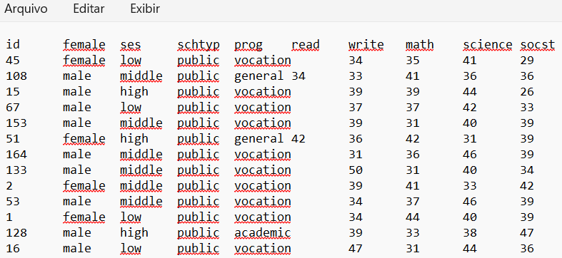

Exemplo de Arquivo TSV

### Lendo Arquivos TSV no R

A leitura de arquivos TSV é muito semelhante à leitura de arquivos CSV, mas alteramos o parâmetro `sep` para `\t`.

```r
# Usando read.table para ler um arquivo TSV
dados_tabulacao <- read.table("dados_tabulacao.txt", header = TRUE, sep = "\t")
str(dados_tabulacao)
```

[output not shown]

Nesta aula, vamos explorar como podemos coletar dados diretamente do usuário dentro do R, permitindo que o próprio usuário insira informações no terminal. Essa técnica é útil para criar formulários interativos ou para capturar entradas específicas durante a execução do código.

## Introdução à Função `scan()`

A função `scan()` permite a entrada de dados diretamente pelo usuário no console. Diferente da leitura de dados de arquivos, a função `scan()` é usada para capturar a entrada do usuário em tempo real. Isso é útil para situações em que precisamos que o usuário forneça informações específicas, como nome, idade, ou qualquer outra entrada.

### Estrutura Básica da Função

A função `scan()` pode ser combinada com outras funções, como `cat()`, para criar interações simples e intuitivas. A função `cat()` é usada para exibir uma mensagem ou pergunta ao usuário, enquanto a função `scan()` captura a resposta.

### Exemplo Alterado: Coletando Informações Pessoais

Vamos criar uma função que solicita o nome, a altura e o peso do usuário, e então calcula o Índice de Massa Corporal (IMC) com base nas informações fornecidas. O IMC é uma medida que pode ser usada para avaliar se uma pessoa está dentro de um peso saudável para sua altura.

```r
calcular_imc <- function() {
    cat("Qual o seu nome?",
        "[Após escrever, pressione ENTER]\n")
    nome <- scan(what = "character", nmax = 1, quiet = TRUE)

    cat("Qual é a sua altura em metros?",
        "[Por exemplo, 1.75]\n")
    altura <- as.numeric(scan(what = "numeric", nmax = 1, quiet = TRUE))

    cat("Qual é o seu peso em quilogramas?",
        "[Por exemplo, 68.5]\n")
    peso <- as.numeric(scan(what = "numeric", nmax = 1, quiet = TRUE))

    # Verificação para garantir que os valores sejam numéricos
    if (is.na(altura) || is.na(peso)) {
        cat("Erro: Certifique-se de que a altura e o peso são números válidos.\n")
        return(NULL)
    }

    imc <- peso / (altura^2)

    cat("Seja bem-vindo(a), ", nome, ".\n", sep = "")
    cat("Seu IMC é ", round(imc, 2), ".\n", sep = "")

    classificacao <- ifelse(imc < 18.5, "Abaixo do peso",
                   ifelse(imc >= 18.5 & imc <= 24.9, "Peso normal",
                   ifelse(imc >= 25 & imc <= 29.9, "Sobrepeso",
                          "Obesidade")))

    cat("Com base no seu IMC, você está na categoria: ", classificacao, ".\n", sep = "")
}

calcular_imc()
```

### Aplicações Práticas

Esta abordagem pode ser expandida para criar formulários mais complexos, onde o usuário insere diversas informações e o R processa essas informações em tempo real. Por exemplo:

- **Formulários de pesquisa**: Capturar respostas a perguntas de uma pesquisa.

- **Sistemas de entrada de dados**: Coletar informações em sistemas simples sem necessidade de interface gráfica.